# 04-02-transforms

In this module, we will learn about transforming data and dimension reduction using principal components analysis.

Load the libraries

### Standardizing data

```
## Rows: 77
## Columns: 16
## $ name     <chr> "100%_Bran", "100%_Natural_Bran", "All-Bran", "All-Bran_with_~
## $ mfr      <chr> "N", "Q", "K", "K", "R", "G", "K", "G", "R", "P", "Q", "G", "~
## $ type     <chr> "C", "C", "C", "C", "C", "C", "C", "C", "C", "C", "C", "C", "~
## $ calories <dbl> 70, 120, 70, 50, 110, 110, 110, 130, 90, 90, 120, 110, 120, 1~
## $ protein  <dbl> 4, 3, 4, 4, 2, 2, 2, 3, 2, 3, 1, 6, 1, 3, 1, 2, 2, 1, 1, 3, 3~
## $ fat      <dbl> 1, 5, 1, 0, 2, 2, 0, 2, 1, 0, 2, 2, 3, 2, 1, 0, 0, 0, 1, 3, 0~
## $ sodium   <dbl> 130, 15, 260, 140, 200, 180, 125, 210, 200, 210, 220, 290, 21~
## $ fiber    <dbl> 10.0, 2.0, 9.0, 14.0, 1.0, 1.5, 1.0, 2.0, 4.0, 5.0, 0.0, 2.0,~
## $ carbo    <dbl> 5.0, 8.0, 7.0, 8.0, 14.0, 10.5, 11.0, 18.0, 15.0, 13.0, 12.0,~
## $ sugars   <dbl> 6, 8, 5, 0, 8, 10, 14, 8, 6, 5, 12, 1, 9, 7, 13, 3, 2, 12, 13~
## $ potass   <dbl> 280, 135, 320, 330, NA, 70, 30, 100, 125, 190, 35, 105, 45, 1~
## $ vitamins <dbl> 25, 0, 25, 25, 25, 25, 25, 25, 25, 25, 25, 25, 25, 25, 25, 25~
## $ shelf    <dbl> 3, 3, 3, 3, 3, 1, 2, 3, 1, 3, 2, 1, 2, 3, 2, 1, 1, 2, 2, 3, 2~
## $ weight   <dbl> 1.00, 1.00, 1.00, 1.00, 1.00, 1.00, 1.00, 1.33, 1.00, 1.00, 1~
## $ cups     <dbl> 0.33, 1.00, 0.33, 0.50, 0.75, 0.75, 1.00, 0.75, 0.67, 0.67, 0~
## $ rating   <dbl> 68.40297, 33.98368, 59.42551, 93.70491, 34.38484, 29.50954, 3~
```

Caret has a nice function to do the various preprocessing steps

```
## Rows: 77
## Columns: 16
## $ name     <chr> "100%_Bran", "100%_Natural_Bran", "All-Bran", "All-Bran_with_~
## $ mfr      <chr> "N", "Q", "K", "K", "R", "G", "K", "G", "R", "P", "Q", "G", "~
## $ type     <chr> "C", "C", "C", "C", "C", "C", "C", "C", "C", "C", "C", "C", "~
## $ calories <dbl> -1.8929836, 0.6732089, -1.8929836, -2.9194605, 0.1599704, 0.1~
## $ protein  <dbl> 1.3286071, 0.4151897, 1.3286071, 1.3286071, -0.4982277, -0.49~
## $ fat      <dbl> -0.01290349, 3.96137277, -0.01290349, -1.00647256, 0.98066557~
## $ sodium   <dbl> -0.3539844, -1.7257708, 1.1967306, -0.2346986, 0.4810160, 0.2~
## $ fiber    <dbl> 3.29284661, -0.06375361, 2.87327158, 4.97114672, -0.48332864,~
## $ carbo    <dbl> -2.50878291, -1.74099432, -1.99692385, -1.74099432, -0.205417~
## $ sugars   <dbl> -0.234390576, 0.222370547, -0.462771138, -1.604673946, 0.2223~
## $ potass   <dbl> 2.57536849, 0.51602052, 3.14346448, 3.28548848, NA, -0.407135~
## $ vitamins <dbl> -0.1453172, -1.2642598, -0.1453172, -0.1453172, -0.1453172, -~
## $ shelf    <dbl> 0.9515734, 0.9515734, 0.9515734, 0.9515734, 0.9515734, -1.450~
## $ weight   <dbl> -0.1967771, -0.1967771, -0.1967771, -0.1967771, -0.1967771, -~
## $ cups     <dbl> -2.1100340, 0.7690100, -2.1100340, -1.3795303, -0.3052601, -0~
## $ rating   <dbl> 1.83218758, -0.61805706, 1.19309856, 3.63338491, -0.58949895,~
```

In the above, character columns are left untouched while everything else is standardized.

### Principal Components Analysis

For the theory behind principal components, refer to the class discussion. Let us first work with calories and ratings variables. Our objective is to see if we can combine these two variables into another which is a linear combination of these two but captures most of the information contained in these two variables.

```
##     calories         rating
##  Min.   : 50.0   Min.   :18.04
##  1st Qu.:100.0   1st Qu.:33.17
##  Median :110.0   Median :40.40
##  Mean   :106.9   Mean   :42.67
##  3rd Qu.:110.0   3rd Qu.:50.83
##  Max.   :160.0   Max.   :93.70
```

```
##           calories    rating
## calories  379.6309 -188.6816
## rating   -188.6816  197.3263
```

```
##           calories    rating
## calories  1.000000 -0.689376
## rating   -0.689376  1.000000
```

We see that both these variables are highly correlated. Correlation is -0.689376. If we consider the variance of each predictor as the information conveyed by it, we can get the relative information by as the variance/total.variance.

```
##           calories    rating
## calories  65.79879 -32.70287
## rating   -32.70287  34.20121
```

Thus calories carries 65.7987949 percent of the total variation while rating carries 34.2% .

Principal components is the method that will help us find linear combinations of these variables that will capture most of the information.

```
## Importance of components:
##                            PC1    PC2
## Standard deviation     22.3165 8.8844
## Proportion of Variance  0.8632 0.1368
## Cumulative Proportion   0.8632 1.0000
```

```
##                 PC1       PC2
## calories  0.8470535 0.5315077
## rating   -0.5315077 0.8470535
```

For example, for the first cereal, 100% Bran, calories = 70 and rating = 68.4. The averages across the data for these variables are: 106.9 and 42.67. The first principal component for 100% Bran will be $0.847(70-106.9) + (-0.531)(68.4 - 42.67) = -44.92$.

```
##              PC1         PC2
##  [1,] -44.921528  2.19718326
##  [2,]  15.725265 -0.38241646
##  [3,] -40.149935 -5.40721229
##  [4,] -75.310772 12.99912556
##  [5,]   7.041508 -5.35768573
##  [6,]   9.632769 -9.48732727
##  [7,]   7.685031 -6.38325489
##  [8,]  22.572106  7.52030946
##  [9,] -17.731545 -3.50615863
## [10,] -19.960454  0.04601098
```

We can plot various aspects of the analysis to see the transformations that take place.

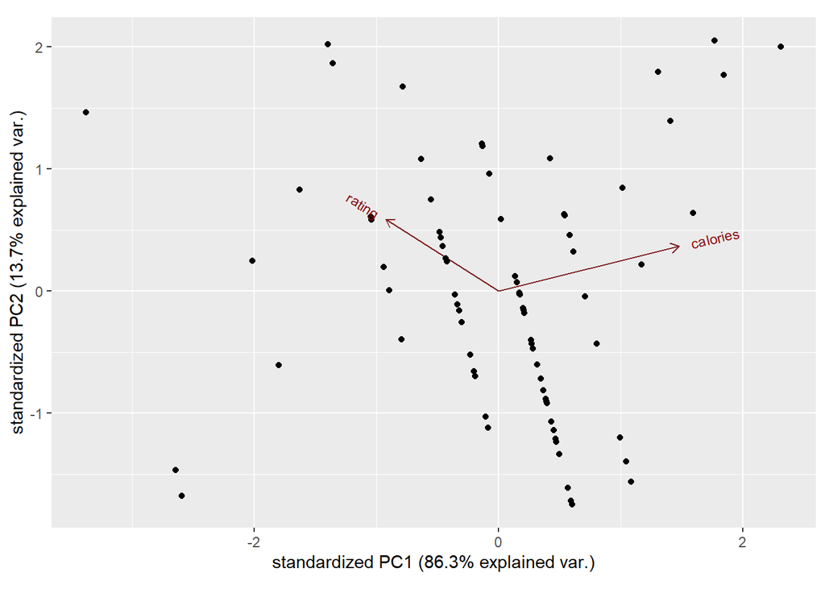

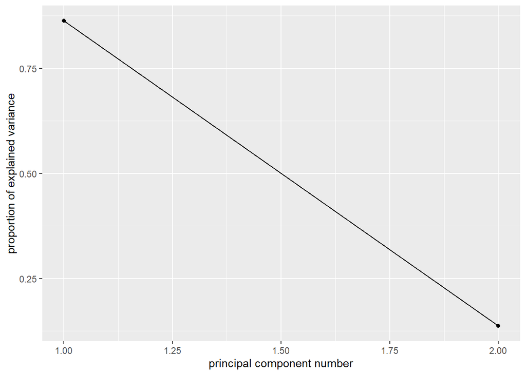

Scree plot: The scree plot tells us the share of variance explained by each of the principal components. Typically, we only include the components above the “elbow”.

One problems with this analysis however is that the scale of these variables is different and the larger variable can dominate the principal components. We should first standardize the variables. Let us now do a complete analysis on the cereals dataset.

```
## Importance of components:
##                           PC1    PC2    PC3     PC4    PC5     PC6     PC7
## Standard deviation     1.9062 1.7743 1.3818 1.00969 0.9947 0.84974 0.81946
## Proportion of Variance 0.2795 0.2422 0.1469 0.07842 0.0761 0.05554 0.05166
## Cumulative Proportion  0.2795 0.5217 0.6685 0.74696 0.8231 0.87861 0.93026
##                            PC8     PC9    PC10    PC11    PC12      PC13
## Standard deviation     0.64515 0.56192 0.30301 0.25194 0.13897 1.499e-08
## Proportion of Variance 0.03202 0.02429 0.00706 0.00488 0.00149 0.000e+00
## Cumulative Proportion  0.96228 0.98657 0.99363 0.99851 1.00000 1.000e+00
```

```
## Standard deviations (1, .., p=13):
##  [1] 1.906202e+00 1.774276e+00 1.381792e+00 1.009691e+00 9.946656e-01
##  [6] 8.497422e-01 8.194611e-01 6.451534e-01 5.619199e-01 3.030079e-01
## [11] 2.519400e-01 1.389658e-01 1.499407e-08
##
## Rotation (n x k) = (13 x 13):
##                  PC1        PC2          PC3         PC4         PC5
## calories  0.29954236  0.3931479 -0.114857453  0.20435870  0.20389885
## protein  -0.30735632  0.1653233 -0.277281953  0.30074318  0.31974897
## fat       0.03991542  0.3457243  0.204890102  0.18683311  0.58689327
## sodium    0.18339651  0.1372205 -0.389431009  0.12033726 -0.33836424
## fiber    -0.45349036  0.1798119 -0.069766079  0.03917361 -0.25511906
## carbo     0.19244902 -0.1494483 -0.562452458  0.08783547  0.18274252
## sugars    0.22806849  0.3514345  0.355405174 -0.02270716 -0.31487243
## potass   -0.40196429  0.3005442 -0.067620183  0.09087843 -0.14836048
## vitamins  0.11598020  0.1729092 -0.387858660 -0.60411064 -0.04928672
## shelf    -0.17126336  0.2650503  0.001531036 -0.63887859  0.32910135
## weight    0.05029930  0.4503085 -0.247138314  0.15342874 -0.22128334
## cups      0.29463553 -0.2122479 -0.139999705  0.04748909  0.12081645
## rating   -0.43837841 -0.2515389 -0.181842433  0.03831622  0.05758420
##                  PC6         PC7          PC8         PC9        PC10
## calories -0.25590627  0.02559550 -0.002477488 -0.02990943  0.49953153
## protein   0.12075193 -0.28270494 -0.426631915 -0.53471801 -0.02156642
## fat       0.34796727  0.05115470  0.063050445  0.45968763 -0.14508724
## sodium    0.66437216  0.28370316  0.176720469 -0.21510290 -0.00109092
## fiber     0.06424358 -0.11232541  0.216215570  0.24433313  0.29510679
## carbo    -0.32639279  0.26046798  0.167436379  0.11680691  0.24055692
## sugars   -0.15208230 -0.22798517 -0.063088121 -0.22538436  0.25165896
## potass    0.02515384 -0.14880826  0.262222466  0.16651285  0.17722073
## vitamins  0.12948578 -0.29427617 -0.457040884  0.34615102  0.05229538
## shelf    -0.05204414  0.17483438  0.414145832 -0.41619893 -0.04610229
## weight   -0.39877368 -0.01392058  0.075247652  0.06507258 -0.69159851
## cups      0.09946094 -0.74856682  0.498958957 -0.04952533 -0.07705936
## rating   -0.18614524 -0.06344456  0.014944982  0.06327447  0.01223508
##                  PC11          PC12          PC13
## calories -0.213580948 -4.921985e-01 -2.339398e-01
## protein   0.032302627  9.969927e-02  1.863851e-01
## fat      -0.066832137  2.914159e-01 -9.013898e-02
## sodium   -0.087460805  5.371283e-02 -2.387372e-01
## fiber    -0.530700425  5.917321e-02  4.417036e-01
## carbo     0.178979001  4.759935e-01  2.250341e-01
## sugars   -0.003250769  6.142503e-01 -1.672565e-01
## potass    0.729209878 -1.207196e-01 -1.275321e-01
## vitamins  0.019464859 -4.477121e-05 -6.043328e-02
## shelf    -0.059398709  1.654411e-02 -1.203515e-09
## weight   -0.112920514 -3.062288e-02 -4.106761e-09
## cups     -0.055325530 -3.213026e-02  1.409513e-09
## rating   -0.275809192  1.892103e-01 -7.428180e-01
```

```
##                  PC1        PC2          PC3         PC4         PC5
## calories  0.29954236  0.3931479 -0.114857453  0.20435870  0.20389885
## protein  -0.30735632  0.1653233 -0.277281953  0.30074318  0.31974897
## fat       0.03991542  0.3457243  0.204890102  0.18683311  0.58689327
## sodium    0.18339651  0.1372205 -0.389431009  0.12033726 -0.33836424
## fiber    -0.45349036  0.1798119 -0.069766079  0.03917361 -0.25511906
## carbo     0.19244902 -0.1494483 -0.562452458  0.08783547  0.18274252
## sugars    0.22806849  0.3514345  0.355405174 -0.02270716 -0.31487243
## potass   -0.40196429  0.3005442 -0.067620183  0.09087843 -0.14836048
## vitamins  0.11598020  0.1729092 -0.387858660 -0.60411064 -0.04928672
## shelf    -0.17126336  0.2650503  0.001531036 -0.63887859  0.32910135
## weight    0.05029930  0.4503085 -0.247138314  0.15342874 -0.22128334
## cups      0.29463553 -0.2122479 -0.139999705  0.04748909  0.12081645
## rating   -0.43837841 -0.2515389 -0.181842433  0.03831622  0.05758420
##                  PC6         PC7          PC8
## calories -0.25590627  0.02559550 -0.002477488
## protein   0.12075193 -0.28270494 -0.426631915
## fat       0.34796727  0.05115470  0.063050445
## sodium    0.66437216  0.28370316  0.176720469
## fiber     0.06424358 -0.11232541  0.216215570
## carbo    -0.32639279  0.26046798  0.167436379
## sugars   -0.15208230 -0.22798517 -0.063088121
## potass    0.02515384 -0.14880826  0.262222466
## vitamins  0.12948578 -0.29427617 -0.457040884
## shelf    -0.05204414  0.17483438  0.414145832
## weight   -0.39877368 -0.01392058  0.075247652
## cups      0.09946094 -0.74856682  0.498958957
## rating   -0.18614524 -0.06344456  0.014944982
```

```
##             PC1        PC2        PC3        PC4        PC5        PC6
## [1,] -5.7080316  1.1794937  0.9772223 -0.4182124 -1.1685135  0.9658729
## [2,] -0.4088663  1.8566366  2.8817488  0.8527139  3.2493523  0.6773167
## [3,] -5.1326841  1.4939138  0.1019413 -0.1682480 -1.5490977  1.9832636
## [4,] -7.8029390 -0.2402565 -0.6720141 -0.4641424 -1.7583375  0.7760803
## [5,]  1.0319894  0.3628765  1.4565472  0.9035855 -0.4050746  0.8900021
## [6,]  1.3774417 -0.2907438  1.4206103 -0.3238797 -0.9364558 -0.4572906
##               PC7        PC8        PC9        PC10        PC11        PC12
## [1,] -0.221692491 -0.2418644  0.1341637  0.04909738 -0.24860818  0.01062868
## [2,] -0.956084412  0.8974454  0.8362807 -0.59062620 -0.06679202 -0.09404952
## [3,]  0.413014999  0.1854209 -0.1392775  0.08369107  0.51370382 -0.01488340
## [4,] -0.694063167  0.8639287  0.6811347  0.10725471 -0.73381450  0.07568271
## [5,] -0.006773274 -0.7887145  0.7393031 -0.09830231 -0.09894110 -0.07989671
## [6,] -0.965869681 -0.2295326 -0.9032987  0.15762123 -0.39216987  0.02146580
##               PC13
## [1,] -1.015211e-08
## [2,] -1.639995e-09
## [3,] -1.463276e-08
## [4,]  1.915278e-08
## [5,] -1.717251e-08
## [6,]  1.978562e-08
```

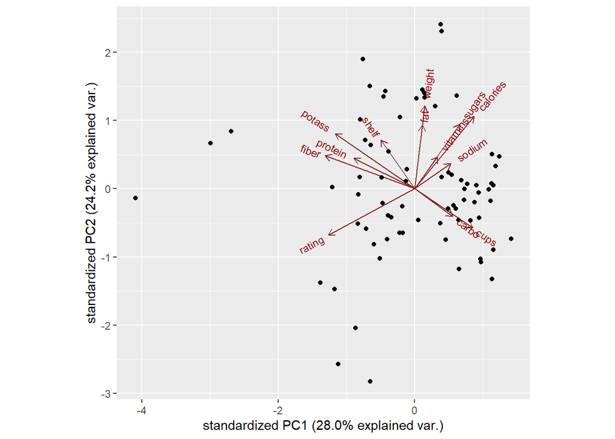

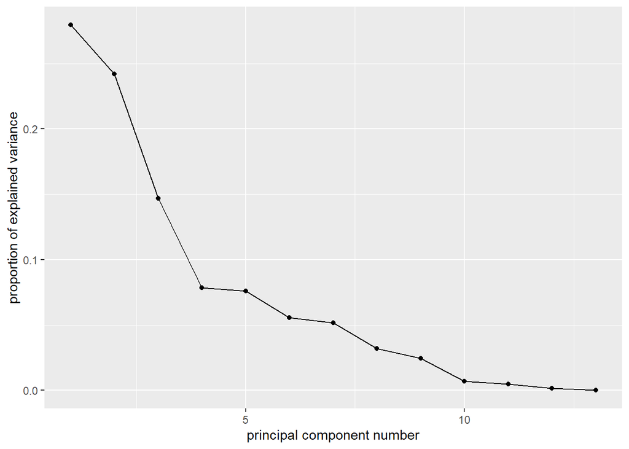

If we wanted to just use pca as an intermediary step to data analysis (for example, regression), we could use `caret` and carry out pca as a preprocessing step.

```
## Created from 74 samples and 13 variables
##
## Pre-processing:
##   - centered (13)
##   - ignored (0)
##   - principal component signal extraction (13)
##   - scaled (13)
##
## PCA needed 8 components to capture 95 percent of the variance
```

```
##                  PC1        PC2          PC3         PC4         PC5
## calories  0.29954236  0.3931479 -0.114857453  0.20435870  0.20389885
## protein  -0.30735632  0.1653233 -0.277281953  0.30074318  0.31974897
## fat       0.03991542  0.3457243  0.204890102  0.18683311  0.58689327
## sodium    0.18339651  0.1372205 -0.389431009  0.12033726 -0.33836424
## fiber    -0.45349036  0.1798119 -0.069766079  0.03917361 -0.25511906
## carbo     0.19244902 -0.1494483 -0.562452458  0.08783547  0.18274252
## sugars    0.22806849  0.3514345  0.355405174 -0.02270716 -0.31487243
## potass   -0.40196429  0.3005442 -0.067620183  0.09087843 -0.14836048
## vitamins  0.11598020  0.1729092 -0.387858660 -0.60411064 -0.04928672
## shelf    -0.17126336  0.2650503  0.001531036 -0.63887859  0.32910135
## weight    0.05029930  0.4503085 -0.247138314  0.15342874 -0.22128334
## cups      0.29463553 -0.2122479 -0.139999705  0.04748909  0.12081645
## rating   -0.43837841 -0.2515389 -0.181842433  0.03831622  0.05758420
##                  PC6         PC7          PC8
## calories -0.25590627  0.02559550 -0.002477488
## protein   0.12075193 -0.28270494 -0.426631915
## fat       0.34796727  0.05115470  0.063050445
## sodium    0.66437216  0.28370316  0.176720469
## fiber     0.06424358 -0.11232541  0.216215570
## carbo    -0.32639279  0.26046798  0.167436379
## sugars   -0.15208230 -0.22798517 -0.063088121
## potass    0.02515384 -0.14880826  0.262222466
## vitamins  0.12948578 -0.29427617 -0.457040884
## shelf    -0.05204414  0.17483438  0.414145832
## weight   -0.39877368 -0.01392058  0.075247652
## cups      0.09946094 -0.74856682  0.498958957
## rating   -0.18614524 -0.06344456  0.014944982
```